# ExtraaLearn Potential Customer Prediction

## Solution by: 'Femi Bolarinwa

## Context

The EdTech industry has been surging in the past decade immensely, and according to a forecast, the Online Education market would be worth $286.62bn by 2023 with a compound annual growth rate (CAGR) of 10.26% from 2018 to 2023. The modern era of online education has enforced a lot in its growth and expansion beyond any limit. Due to having many dominant features like ease of information sharing, personalized learning experience, transparency of assessment, etc, it is now preferable to traditional education.

In the present scenario due to the Covid-19, the online education sector has witnessed rapid growth and is attracting a lot of new customers. Due to this rapid growth, many new companies have emerged in this industry. With the availability and ease of use of digital marketing resources, companies can reach out to a wider audience with their offerings. The customers who show interest in these offerings are termed as leads. There are various sources of obtaining leads for Edtech companies, like

- The customer interacts with the marketing front on social media or other online platforms.
- The customer browses the website/app and downloads the brochure
- The customer connects through emails for more information.

The company then nurtures these leads and tries to convert them to paid customers. For this, the representative from the organization connects with the lead on call or through email to share further details.

## Objective

ExtraaLearn is an initial stage startup that offers programs on cutting-edge technologies to students and professionals to help them upskill/reskill. With a large number of leads being generated regularly, one of the issues faced by ExtraaLearn is to identify which of the leads are more likely to convert so that they can allocate resources accordingly. You, as a data scientist at ExtraaLearn, have been provided the leads data to:

- Analyze and build an ML model to help identify which leads are more likely to convert to paid customers,
- Find the factors driving the lead conversion process
- Create a profile of the leads which are likely to convert

## Data Description

The data contains the different attributes of leads and their interaction details with ExtraaLearn. The detailed data dictionary is given below.

**Data Dictionary**

- ID: ID of the lead
- age: Age of the lead
- current_occupation: Current occupation of the lead. Values include 'Professional','Unemployed',and 'Student'
- first_interaction: How did the lead first interact with ExtraaLearn. Values include 'Website', 'Mobile App'
- profile_completed: What percentage of the profile has been filled by the lead on the website/mobile app. Values include Low - (0-50%), Medium - (50-75%), High (75-100%)
- website_visits: How many times has a lead visited the website
- time_spent_on_website: Total time spent on the website
- page_views_per_visit: Average number of pages on the website viewed during the visits.
- last_activity: Last interaction between the lead and ExtraaLearn.
  - Email Activity: Seeking for details about the program through email, Representative shared information with a lead like a brochure of program, etc
  - Phone Activity: Had a Phone Conversation with a representative, Had conversation over SMS with a representative, etc
  - Website Activity: Interacted on live chat with a representative, Updated profile on the website, etc
- print_media_type1: Flag indicating whether the lead had seen the ad of ExtraaLearn in the Newspaper.
- print_media_type2: Flag indicating whether the lead had seen the ad of ExtraaLearn in the Magazine.
- digital_media: Flag indicating whether the lead had seen the ad of ExtraaLearn on the digital platforms.
- educational_channels: Flag indicating whether the lead had heard about ExtraaLearn in the education channels like online forums, discussion threads, educational websites, etc.
- referral: Flag indicating whether the lead had heard about ExtraaLearn through reference.
- status: Flag indicating whether the lead was converted to a paid customer or not.

## **Solution Content Overview:**

- **Libraries importation**
- **Data Overview**
- **Exploratory Data Analysis (EDA)**
- **Data pre-processing**
- **Modeling**
  - Decision Tree
  - Random Forest
  - Bagging
  - Logistic Regression
  - KNN
  - LDA
  - QDA
  - AdaBoost
  - Gradient Boost
  - XGBoost
- **Cross Validation and Evaluation**
- **Hyperparameter Tuning**
- **Business Insights and Recommendation**

## Libraries importation

```python
#Libraries to help with reading and manipulating data
import pandas as pd
import numpy as np

#Libaries for data visualization
import matplotlib.pyplot as plt
import seaborn as sns

# Removes the limit for the number of displayed columns
pd.set_option("display.max_columns", None)
# Sets the limit for the number of displayed rows
pd.set_option("display.max_rows", 200)
# setting the precision of floating numbers to 3 decimal points
pd.set_option("display.float_format", lambda x: "%.3f" % x)

#Libraries to build models for prediction
from sklearn.linear_model import LogisticRegression
from sklearn.tree import DecisionTreeClassifier
from sklearn import tree
from sklearn.neighbors import KNeighborsClassifier
from sklearn.discriminant_analysis import LinearDiscriminantAnalysis, QuadraticDiscriminantAnalysis
from sklearn.ensemble import AdaBoostClassifier, GradientBoostingClassifier, BaggingClassifier, RandomForestClassifier
from xgboost import XGBClassifier

#Library for cross validation
from sklearn.model_selection import cross_val_score
#Library to tune different models
from sklearn.model_selection import GridSearchCV
# Library to split data
from sklearn.model_selection import train_test_split

#Libraries for model perfomance evaluation
from sklearn.metrics import (f1_score, accuracy_score, recall_score, precision_score, confusion_matrix, roc_auc_score,
    plot_confusion_matrix, precision_recall_curve, roc_curve, make_scorer, classification_report)

import warnings
warnings.filterwarnings("ignore")
from statsmodels.tools.sm_exceptions import ConvergenceWarning
warnings.simplefilter("ignore", ConvergenceWarning)
```

## Data Overview

```python
learn = pd.read_csv("ExtraaLearn.csv")
```

```python
data = learn.copy() #keeping original copy of dataframe
```

```python
data.head() # Viewing the first and last 5 rows of the dataset to ensure right dataset is loaded
```

|  | ID | age | current_occupation | first_interaction | profile_completed | website_visits | time_spent_on_website | page_views_per_visit | last_activity | print_media_type1 | print_media_type2 | digital_media | educational_channels | referral | status |
| --- | --- | --- | --- | --- | --- | --- | --- | --- | --- | --- | --- | --- | --- | --- | --- |
| 0 | EXT001 | 57 | Unemployed | Website | High | 7 | 1639 | 1.861 | Website Activity | Yes | No | Yes | No | No | 1 |
| 1 | EXT002 | 56 | Professional | Mobile App | Medium | 2 | 83 | 0.320 | Website Activity | No | No | No | Yes | No | 0 |
| 2 | EXT003 | 52 | Professional | Website | Medium | 3 | 330 | 0.074 | Website Activity | No | No | Yes | No | No | 0 |
| 3 | EXT004 | 53 | Unemployed | Website | High | 4 | 464 | 2.057 | Website Activity | No | No | No | No | No | 1 |
| 4 | EXT005 | 23 | Student | Website | High | 4 | 600 | 16.914 | Email Activity | No | No | No | No | No | 0 |

```python
data.tail()
```

|  | ID | age | current_occupation | first_interaction | profile_completed | website_visits | time_spent_on_website | page_views_per_visit | last_activity | print_media_type1 | print_media_type2 | digital_media | educational_channels | referral | status |
| --- | --- | --- | --- | --- | --- | --- | --- | --- | --- | --- | --- | --- | --- | --- | --- |
| 4607 | EXT4608 | 35 | Unemployed | Mobile App | Medium | 15 | 360 | 2.170 | Phone Activity | No | No | No | Yes | No | 0 |
| 4608 | EXT4609 | 55 | Professional | Mobile App | Medium | 8 | 2327 | 5.393 | Email Activity | No | No | No | No | No | 0 |
| 4609 | EXT4610 | 58 | Professional | Website | High | 2 | 212 | 2.692 | Email Activity | No | No | No | No | No | 1 |
| 4610 | EXT4611 | 57 | Professional | Mobile App | Medium | 1 | 154 | 3.879 | Website Activity | Yes | No | No | No | No | 0 |
| 4611 | EXT4612 | 55 | Professional | Website | Medium | 4 | 2290 | 2.075 | Phone Activity | No | No | No | No | No | 0 |

**Observation:**

- The intended data set was loaded.

### Shape of the dataset

```python
data.shape
```

```
(4612, 15)
```

**Observation:**

- Data has 4612 rows and 15 columns

### Data types of the columns

```python
data.info()
```

```
<class 'pandas.core.frame.DataFrame'>
RangeIndex: 4612 entries, 0 to 4611
Data columns (total 15 columns):
 #   Column                 Non-Null Count  Dtype
---  ------                 --------------  -----
 0   ID                     4612 non-null   object
 1   age                    4612 non-null   int64
 2   current_occupation     4612 non-null   object
 3   first_interaction      4612 non-null   object
 4   profile_completed      4612 non-null   object
 5   website_visits         4612 non-null   int64
 6   time_spent_on_website  4612 non-null   int64
 7   page_views_per_visit   4612 non-null   float64
 8   last_activity          4612 non-null   object
 9   print_media_type1      4612 non-null   object
 10  print_media_type2      4612 non-null   object
 11  digital_media          4612 non-null   object
 12  educational_channels   4612 non-null   object
 13  referral               4612 non-null   object
 14  status                 4612 non-null   int64
dtypes: float64(1), int64(4), object(10)
memory usage: 540.6+ KB
```

**Observation:**

- All columns appear to have appropriate data types
- No missing values

```python
# checking for duplicate values
data.duplicated().sum()
```

```
0
```

**Observation:**

- No duplicate rows

## Exploratory Data Analysis

**Checking the statistical summary of the data.**

```python
data.describe().T
```

|  | count | mean | std | min | 25% | 50% | 75% | max |
| --- | --- | --- | --- | --- | --- | --- | --- | --- |
| age | 4612.000 | 46.201 | 13.161 | 18.000 | 36.000 | 51.000 | 57.000 | 63.000 |
| website_visits | 4612.000 | 3.567 | 2.829 | 0.000 | 2.000 | 3.000 | 5.000 | 30.000 |
| time_spent_on_website | 4612.000 | 724.011 | 743.829 | 0.000 | 148.750 | 376.000 | 1336.750 | 2537.000 |
| page_views_per_visit | 4612.000 | 3.026 | 1.968 | 0.000 | 2.078 | 2.792 | 3.756 | 18.434 |
| status | 4612.000 | 0.299 | 0.458 | 0.000 | 0.000 | 0.000 | 1.000 | 1.000 |

**Observation:**

- 25% of customers are 36 or younger
- On average, a customer visited the website ~4 times
- Half of the customer spend 376seconds or less on the webpage
- 75% viewed ~4 pages or less per visit

**Checking the number of each unique value for each categorical variable.**

```python
# Making a list of all catrgorical variables
cat_col = list(data.select_dtypes("object").columns)

# Printing number of count of each unique value in each column
for column in cat_col:
    print(data[column].value_counts())
    print("-" * 50)
```

```
EXT001     1
EXT2884    1
EXT3080    1
EXT3079    1
EXT3078    1
          ..
EXT1537    1
EXT1536    1
EXT1535    1
EXT1534    1
EXT4612    1
Name: ID, Length: 4612, dtype: int64
--------------------------------------------------
Professional    2616
Unemployed      1441
Student          555
Name: current_occupation, dtype: int64
--------------------------------------------------
Website       2542
Mobile App    2070
Name: first_interaction, dtype: int64
--------------------------------------------------
High      2264
Medium    2241
Low        107
Name: profile_completed, dtype: int64
--------------------------------------------------
Email Activity      2278
Phone Activity      1234
Website Activity    1100
Name: last_activity, dtype: int64
--------------------------------------------------
No     4115
Yes     497
Name: print_media_type1, dtype: int64
--------------------------------------------------
No     4379
Yes     233
Name: print_media_type2, dtype: int64
--------------------------------------------------
No     4085
Yes     527
Name: digital_media, dtype: int64
--------------------------------------------------
No     3907
Yes     705
Name: educational_channels, dtype: int64
--------------------------------------------------
No     4519
Yes      93
Name: referral, dtype: int64
--------------------------------------------------
```

**Observation:**

- ID appears to be unique for all 4612 observations
- 3 unique current_occupation
- 2 unique first_interaction medium
- 3 unique profile_completed stages
- 3 unique last_activity tyoes

```python
# checking the number of unique IDs
data["ID"].nunique()
```

```
4612
```

**Removing ID column since its unique and provides no predictive power.**

```python
data.drop(["ID"], axis=1, inplace=True)
```

```python
data.shape
```

```
(4612, 14)
```

### Univariate Analysis

```python
# custom function to plot a boxplot and a histogram along the same scale.
def histogram_boxplot(data, feature, figsize=(12, 4), kde=False, bins=None):
    """
    Boxplot and histogram combined

    data: dataframe
    feature: dataframe column
    figsize: size of figure (default (12,7))
    kde: whether to the show density curve (default False)
    bins: number of bins for histogram (default None)
    """
    f2, (ax_box2, ax_hist2) = plt.subplots(
        nrows=2,  # Number of rows of the subplot grid= 2
        sharex=True,  # x-axis will be shared among all subplots
        gridspec_kw={"height_ratios": (0.25, 0.75)},
        figsize=figsize,
    )  # creating the 2 subplots
    sns.boxplot(
        data=data, x=feature, ax=ax_box2, showmeans=True, color="violet"
    )  # boxplot will be created and a star will indicate the mean value of the column
    sns.histplot(
        data=data, x=feature, kde=kde, ax=ax_hist2, bins=bins, palette="winter"
    ) if bins else sns.histplot(
        data=data, x=feature, kde=kde, ax=ax_hist2
    )  # For histogram
    ax_hist2.axvline(
        data[feature].mean(), color="green", linestyle="--"
    )  # Add mean to the histogram
    ax_hist2.axvline(
        data[feature].median(), color="black", linestyle="-"
    )  # Add median to the histogram
```

### Observations on age

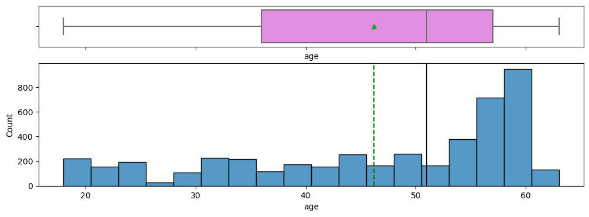

```python
histogram_boxplot(data, "age")
```

**Observation:**

### Observations on website_visits

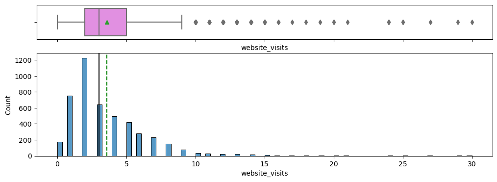

```python
histogram_boxplot(data, "website_visits")
```

**Observation:**

- Distribution of web visits is right skewed
- Has lots of outliers
- 25% of leads visited 5 times or more

```python
# To check how many leads have not visited web-site
data[data["website_visits"] == 0].shape
```

```
(174, 14)
```

**Observation:**

- 174 customers have not used the website

### Observations on time_spent_on_website

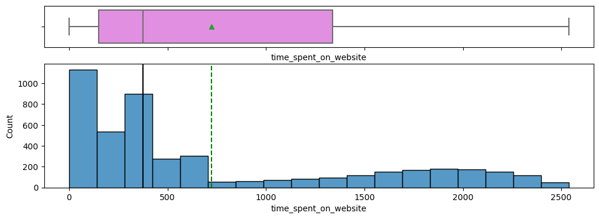

```python
histogram_boxplot(data,"time_spent_on_website")
```

**Observation:**

- Distribution is right skewed
- No outliers

### Observations on number of page_views_per_visit

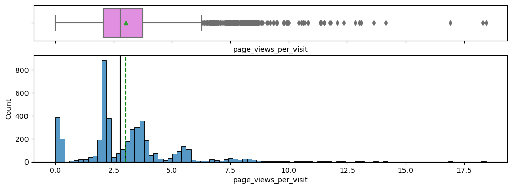

```python
histogram_boxplot(data, "page_views_per_visit")
```

**Observation:**

- Distribution is right skewed with lots of outliers

```python
# function to create labeled barplots for categorical variables

def labeled_barplot(data, feature, perc=False, n=None):
    """
    Barplot with percentage at the top

    data: dataframe
    feature: dataframe column
    perc: whether to display percentages instead of count (default is False)
    n: displays the top n category levels (default is None, i.e., display all levels)
    """

    total = len(data[feature])  # length of the column
    count = data[feature].nunique()
    if n is None:
        plt.figure(figsize=(count + 1, 3))
    else:
        plt.figure(figsize=(n + 1, 3))

    plt.xticks(rotation=25, fontsize=8)
    ax = sns.countplot(
        data=data,
        x=feature,
        palette="Paired",
        order=data[feature].value_counts().index[:n].sort_values(),
    )

    for p in ax.patches:
        if perc == True:
            label = "{:.1f}%".format(
                100 * p.get_height() / total
            )  # percentage of each class of the category
        else:
            label = p.get_height()  # count of each level of the category

        x = p.get_x() + p.get_width() / 2  # width of the plot
        y = p.get_height()  # height of the plot

        ax.annotate(
            label,
            (x, y),
            ha="center",
            va="center",
            size=12,
            xytext=(0, 5),
            textcoords="offset points",
        )  # annotate the percentage

    plt.show()  # show the plot
```

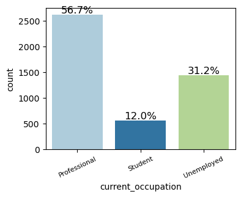

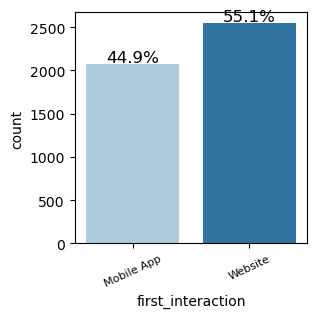

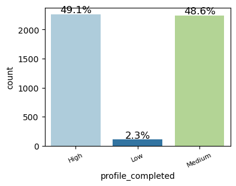

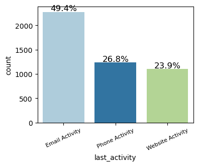

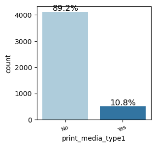

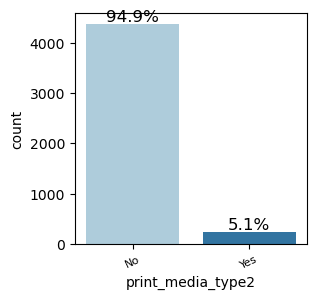

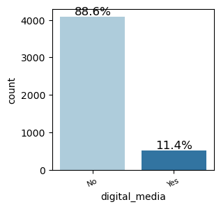

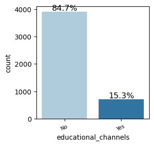

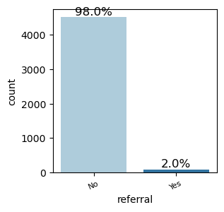

```python
cat_col = list(data.select_dtypes("object").columns)
for col in cat_col:
    labeled_barplot(data, col, perc=True)
```

**Observations**

- Most leads are professionals.
- More first interactions took place on the web compared to mobile app
- There are roughly as many 'high' and 'medium' completed profiles
- significantly more leads were not referred

### Bivariate Analysis

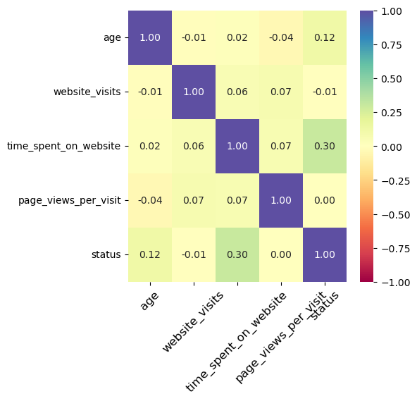

```python
cols_list = data.select_dtypes(include=np.number).columns.tolist()

plt.figure(figsize=(5, 5))
sns.heatmap(
    data[cols_list].corr(), annot=True, vmin=-1, vmax=1, fmt=".2f", cmap="Spectral"
)
plt.xticks(rotation=45, fontsize=12)
plt.show()
```

Observation:

- No significant correlation among numerical variables

**Creating functions that will help with further analysis.**

```python
### function to plot distributions wrt target
def distribution_plot_wrt_target(data, predictor, target):

    fig, axs = plt.subplots(2, 2, figsize=(12, 5))

    target_uniq = data[target].unique()

    axs[0, 0].set_title("Distribution of target for target=" + str(target_uniq[0]))
    sns.histplot(
        data=data[data[target] == target_uniq[0]],
        x=predictor,
        kde=True,
        ax=axs[0, 0],
        color="teal",
        stat="density",
    )

    axs[0, 1].set_title("Distribution of target for target=" + str(target_uniq[1]))
    sns.histplot(
        data=data[data[target] == target_uniq[1]],
        x=predictor,
        kde=True,
        ax=axs[0, 1],
        color="orange",
        stat="density",
    )

    axs[1, 0].set_title("Boxplot w.r.t target")
    sns.boxplot(data=data, x=target, y=predictor, ax=axs[1, 0], palette="gist_rainbow")

    axs[1, 1].set_title("Boxplot (without outliers) w.r.t target")
    sns.boxplot(
        data=data,
        x=target,
        y=predictor,
        ax=axs[1, 1],
        showfliers=False,
        palette="gist_rainbow",
    )

    plt.tight_layout()
    plt.show()
```

```python
def stacked_barplot(data, predictor, target):
    """
    Print the category counts and plot a stacked bar chart

    data: dataframe
    predictor: independent variable
    target: target variable
    """
    count = data[predictor].nunique()
    sorter = data[target].value_counts().index[-1]
    tab1 = pd.crosstab(data[predictor], data[target], margins=True).sort_values(
        by=sorter, ascending=False
    )
    print(tab1)
    print("-" * 120)
    tab = pd.crosstab(data[predictor], data[target], normalize="index").sort_values(
        by=sorter, ascending=False
    )
    tab.plot(kind="bar", stacked=True, figsize=(count + 5, 4))
    plt.legend(
        loc="lower left", frameon=False,
    )
    plt.legend(loc="upper left", bbox_to_anchor=(1, 1))
    plt.show()
```

**Leads will have different expectations from the outcome of the course and the current occupation may play a key role for them to take the program**

```
status                 0     1   All
current_occupation
All                 3235  1377  4612
Professional        1687   929  2616
Unemployed          1058   383  1441
Student              490    65   555
------------------------------------------------------------------------------------------------------------------------
```

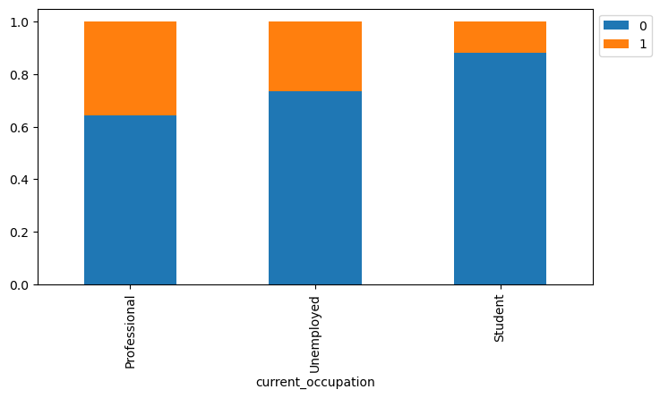

```python
stacked_barplot(data, "current_occupation", "status")
```

Observation:

- Majority of each current occupation category were not converted

**Age can be a good factor to differentiate between such leads**

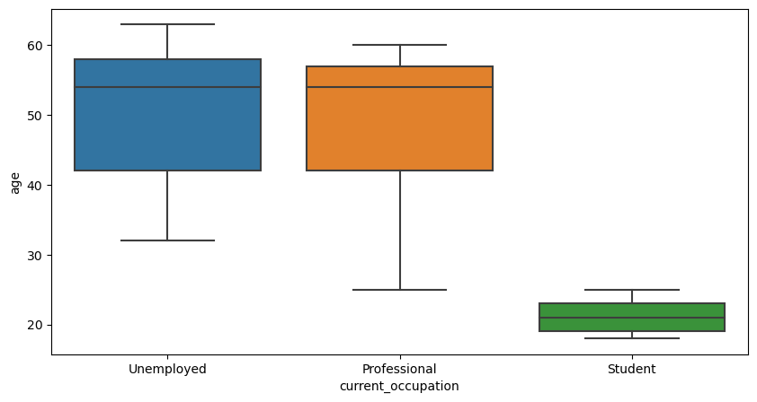

```python
plt.figure(figsize=(10, 5))
sns.boxplot(data["current_occupation"], data["age"])
plt.show()
```

```python
data.groupby(["current_occupation"])["age"].describe()
```

| current_occupation | count | mean | std | min | 25% | 50% | 75% | max |
| --- | --- | --- | --- | --- | --- | --- | --- | --- |
| Professional | 2616.000 | 49.347 | 9.891 | 25.000 | 42.000 | 54.000 | 57.000 | 60.000 |
| Student | 555.000 | 21.144 | 2.001 | 18.000 | 19.000 | 21.000 | 23.000 | 25.000 |
| Unemployed | 1441.000 | 50.140 | 10.000 | 32.000 | 42.000 | 54.000 | 58.000 | 63.000 |

Observation:

- Young people make up the student occupation which is the least occupation category with leads conversion

**The company's first interaction with leads should be compelling and persuasive. I'll check if the channels of the first interaction have an impact on the conversion of leads**

```
status                0     1   All
first_interaction
All                3235  1377  4612
Website            1383  1159  2542
Mobile App         1852   218  2070
------------------------------------------------------------------------------------------------------------------------
```

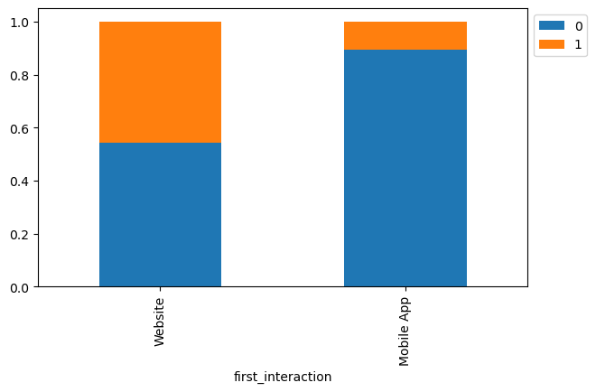

```python
stacked_barplot(data,"first_interaction", "status")
```

Observation:

- First interactions on the website are more likely to convert

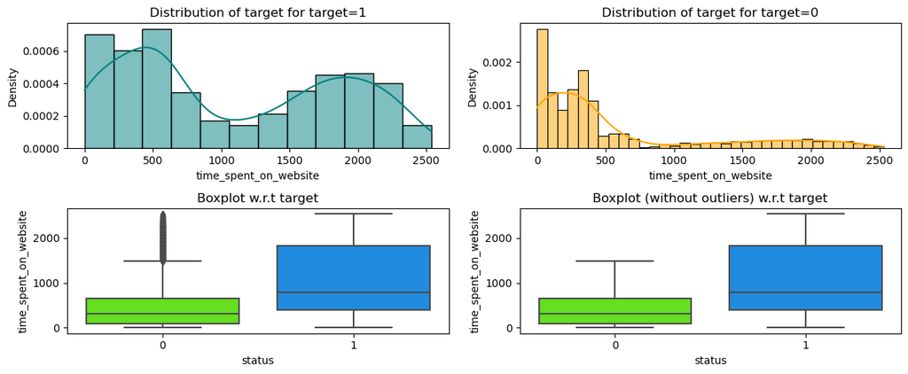

```python
distribution_plot_wrt_target(data, "time_spent_on_website", "status")
```

Observation:

- Converted leads tend to spend more time on the website
- Distribution of time spent on website for converted leads is bi-modal

```python
# checking the median value
data.groupby(["status"])["time_spent_on_website"].median()
```

```
status
0   317.000
1   789.000
Name: time_spent_on_website, dtype: float64
```

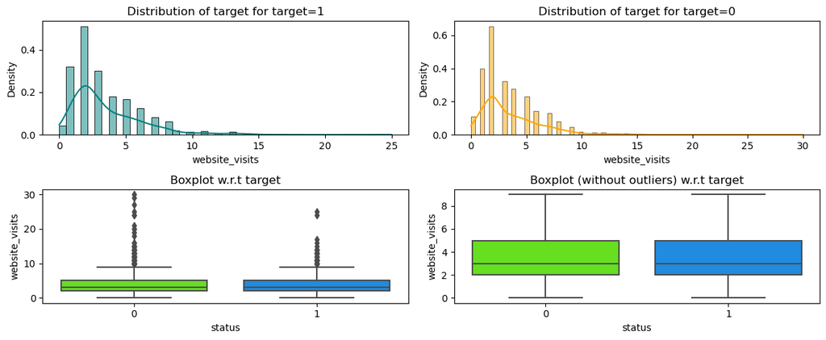

```python
distribution_plot_wrt_target(data, "website_visits", "status")
```

Observation:

- Distribution of website visits similar for both converted and unconverted leads

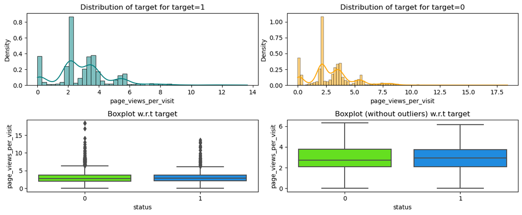

```python
distribution_plot_wrt_target(data, "page_views_per_visit", "status")
```

Observation:

- Distribution of pages view per visits similar for both converted and unconverted leads

**People browsing the website or the mobile app are generally required to create a profile by sharing their personal details before they can access more information. I'll check if the profile completion level has an impact on lead status**

```
status                0     1   All
profile_completed
All                3235  1377  4612
High               1318   946  2264
Medium             1818   423  2241
Low                  99     8   107
------------------------------------------------------------------------------------------------------------------------
```

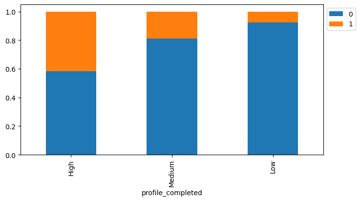

```python
stacked_barplot(data,"profile_completed","status")
```

Observation:

- Better completed profiles tend to lead to more conversion

**After a lead shares their information by creating a profile, there may be interactions between the lead and the company to proceed with the process of enrollment. I'll check how the last activity impacts lead conversion status**

```
status               0     1   All
last_activity
All               3235  1377  4612
Email Activity    1587   691  2278
Website Activity   677   423  1100
Phone Activity     971   263  1234
------------------------------------------------------------------------------------------------------------------------
```

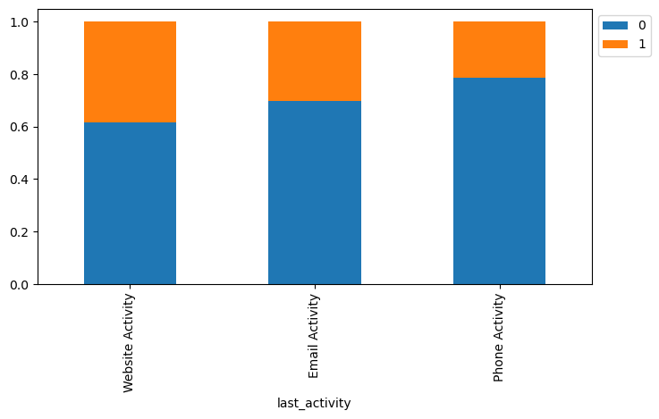

```python
stacked_barplot(data,"last_activity","status")
```

Observation:

- Last activity on the website tends to cause lead conversion than on email and phone

**I'll see how advertisement and referrals impact the lead status**

```
status                0     1   All
print_media_type1
All                3235  1377  4612
No                 2897  1218  4115
Yes                 338   159   497
------------------------------------------------------------------------------------------------------------------------
```

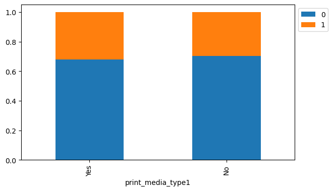

```python
stacked_barplot(data, "print_media_type1","status")
```

Observation:

- No significant disparity between categories of print media type1 with respect to causing lead conversion

```
status                0     1   All
print_media_type2
All                3235  1377  4612
No                 3077  1302  4379
Yes                 158    75   233
------------------------------------------------------------------------------------------------------------------------
```

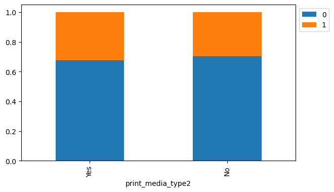

```python
stacked_barplot(data, "print_media_type2","status")
```

Observation:

- No significant disparity between categories of print media type2 with respect to causing lead conversion

```
status            0     1   All
digital_media
All            3235  1377  4612
No             2876  1209  4085
Yes             359   168   527
------------------------------------------------------------------------------------------------------------------------
```

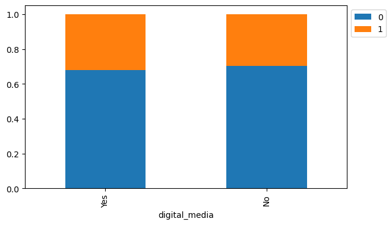

```python
stacked_barplot(data, "digital_media", "status")
```

Observation:

- No significant disparity between categories of digital media with respect to causing lead conversion

```
status                   0     1   All
educational_channels
All                   3235  1377  4612
No                    2727  1180  3907
Yes                    508   197   705
------------------------------------------------------------------------------------------------------------------------
```

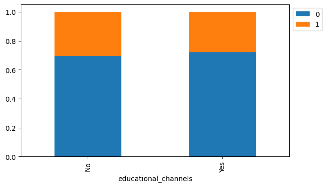

```python
stacked_barplot(data,"educational_channels","status")
```

Observation:

- No significant disparity between categories of educational channels with respect to causing lead conversion

```
status       0     1   All
referral
All       3235  1377  4612
No        3205  1314  4519
Yes         30    63    93
------------------------------------------------------------------------------------------------------------------------
```

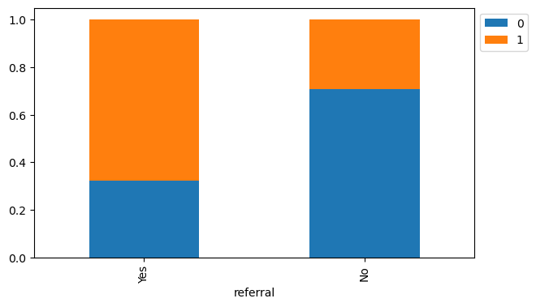

```python
stacked_barplot(data, "referral","status")
```

Observation:

- Referred leads are more likely to convert

### Outlier Check

- I'll check for outliers in the data.

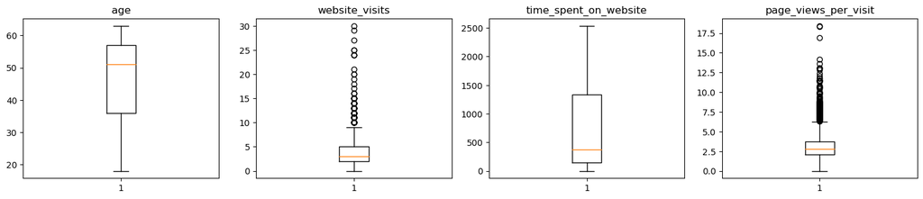

```python
# outlier detection using boxplot
numeric_columns = data.select_dtypes(include=np.number).columns.tolist()
# dropping release_year as it is a temporal variable
numeric_columns.remove("status")

plt.figure(figsize=(15, 12))

for i, variable in enumerate(numeric_columns):
    plt.subplot(4, 4, i + 1)
    plt.boxplot(data[variable], whis=1.5)
    plt.tight_layout()
    plt.title(variable)

plt.show()
```

**Observations:**

- number of website visits and page views per visit have similar distribution with significant outliers.

### Data Preparation for modeling

```python
X = data.drop(["status"], axis=1)
Y = data["status"]

X = pd.get_dummies(X, drop_first=True)

# Splitting the data in 70:30 ratio for train to test data
X_train, X_test, y_train, y_test = train_test_split(
    X, Y, test_size=0.30, random_state=1
)
```

```python
print("Shape of Training set : ", X_train.shape)
print("Shape of test set : ", X_test.shape)
print("Percentage of classes in training set:")
print(y_train.value_counts(normalize=True))
print("Percentage of classes in test set:")
print(y_test.value_counts(normalize=True))
```

```
Shape of Training set :  (3228, 16)
Shape of test set :  (1384, 16)
Percentage of classes in training set:
0   0.704
1   0.296
Name: status, dtype: float64
Percentage of classes in test set:
0   0.695
1   0.305
Name: status, dtype: float64
```

## **Building Classification Models**

### Model evaluation criterion

### Model can make wrong predictions as:

1. Predicting a lead will not be converted to a paid customer in reality, the lead would have converted to a paid customer.
2. Predicting a lead will be converted to a paid customer in reality, the lead would not have converted to a paid customer.

### Which case is more important?

- If I predict that a lead will not get converted and the lead would have converted then the company will lose a potential customer.
- If I predict that a lead will get converted and the lead doesn't get converted the company might lose resources by nurturing false-positive cases.

Losing a potential customer is a greater loss.

### How to reduce the losses?

- Company would want `Recall` to be maximized, greater the Recall score higher are the chances of minimizing False Negatives.

#### First, I'll create functions to calculate different metrics and confusion matrix so that I don't have to use the same code repeatedly for each model.

```python
def make_confusion_matrix(cf,
                          group_names=None,
                          categories='auto',
                          count=True,
                          percent=True,
                          cbar=True,
                          xyticks=True,
                          xyplotlabels=True,
                          sum_stats=True,
                          figsize=None,
                          cmap='Blues',
                          title=None):
    '''
    This function will make a pretty plot of an sklearn Confusion Matrix cm using a Seaborn heatmap visualization.
    Arguments
    '''


    # CODE TO GENERATE TEXT INSIDE EACH SQUARE
    blanks = ['' for i in range(cf.size)]

    if group_names and len(group_names)==cf.size:
        group_labels = ["{}\n".format(value) for value in group_names]
    else:
        group_labels = blanks

    if count:
        group_counts = ["{0:0.0f}\n".format(value) for value in cf.flatten()]
    else:
        group_counts = blanks

    if percent:
        group_percentages = ["{0:.2%}".format(value) for value in cf.flatten()/np.sum(cf)]
    else:
        group_percentages = blanks

    box_labels = [f"{v1}{v2}{v3}".strip() for v1, v2, v3 in zip(group_labels,group_counts,group_percentages)]
    box_labels = np.asarray(box_labels).reshape(cf.shape[0],cf.shape[1])


    # CODE TO GENERATE SUMMARY STATISTICS & TEXT FOR SUMMARY STATS
    if sum_stats:
        #Accuracy is sum of diagonal divided by total observations
        accuracy  = np.trace(cf) / float(np.sum(cf))



    # SET FIGURE PARAMETERS ACCORDING TO OTHER ARGUMENTS
    if figsize==None:
        #Get default figure size if not set
        figsize = plt.rcParams.get('figure.figsize')

    if xyticks==False:
        #Do not show categories if xyticks is False
        categories=False


    # MAKE THE HEATMAP VISUALIZATION
    plt.figure(figsize=figsize)
    sns.heatmap(cf,annot=box_labels,fmt="",cmap=cmap,cbar=cbar,xticklabels=categories,yticklabels=categories)
    plt.ylabel('Actual')
    plt.xlabel('Predicted')
    plt.figure(figsize = (3, 3))


    if title:
        plt.title(title)
```

## Decision Tree

#### Building Decision Tree Model

```python
# Fitting the decision tree classifier on the training data
d_tree = DecisionTreeClassifier(random_state=1)
d_tree.fit(X_train, y_train)
```

```
DecisionTreeClassifier(random_state=1)
```

#### Model Evaluation using K-Fold Cross Validation on Training data

```python
scores = cross_val_score(d_tree, X_train, y_train, cv=20)
print(f"The average accuracy score of the model with K-20 Cross validation is {np.average(scores)} ")
```

```
The average accuracy score of the model with K-20 Cross validation is 0.7943064182194617
```

**Performance on test data to see if the model is overfitting.**

```python
# Checking performance on the unseen testing data
y_pred_test1 = d_tree.predict(X_test)
```

```
              precision    recall  f1-score   support

           0       0.87      0.86      0.86       962
           1       0.69      0.70      0.70       422

    accuracy                           0.81      1384
   macro avg       0.78      0.78      0.78      1384
weighted avg       0.81      0.81      0.81      1384
```

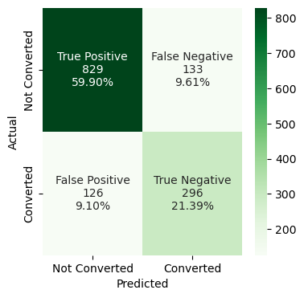

```python
#Calculating the confusion matrix
print(classification_report(y_test, y_pred_test1))
cm=confusion_matrix(y_test, y_pred_test1)
labels = ['True Positive','False Negative','False Positive','True Negative']
categories = [ 'Not Converted','Converted']
make_confusion_matrix(cm,
                      group_names=labels,
                      categories=categories,
                      figsize=(4,4),
                      cmap='Greens')
```

**Observations:**

- ~80% classification accuracy on both training and test dataset. Model not overfitting
- Model giving a generalized performance.
- 78% average recall score. Could be better
- Divergent recall score for converted and unconverted leads

**I'll try hyperparameter tuning using GridSearchCV to find the optimal max_depth** to optimize the model. I'll tune some other hyperparameters as well.

### **Decision Tree - Hyperparameter Tuning**

I'll use the class_weight hyperparameter with the value equal to {0: 0.3, 1: 0.7} which is approximately the opposite of the imbalance in the original data.

**This would tell the model that 1 is the important class here.**

```python
# Choose the type of classifier
d_tree_tuned = DecisionTreeClassifier(random_state = 7, class_weight = {0: 0.3, 1: 0.7})

# Grid of parameters to choose from
parameters = {'max_depth': np.arange(2, 10),
              'criterion': ['gini', 'entropy'],
              'min_samples_leaf': [5, 10, 20, 25]
             }

# Type of scoring used to compare parameter combinations - recall score for class 1
scorer = make_scorer(recall_score, pos_label = 1)

# Run the grid search
grid_obj = GridSearchCV(d_tree_tuned, parameters, scoring = scorer, cv = 5)

grid_obj = grid_obj.fit(X_train, y_train)

# Set the classifier to the best combination of parameters
d_tree_tuned = grid_obj.best_estimator_

# Fit the best algorithm to the data
d_tree_tuned.fit(X_train, y_train)
```

```
DecisionTreeClassifier(class_weight={0: 0.3, 1: 0.7}, criterion='entropy',
                       max_depth=3, min_samples_leaf=5, random_state=7)
```

I have tuned the model and fit the tuned model on the training data. Now, **I'll check the model performance on the training and testing data.**

#### Checking model performance on train and test set

```python
# Checking performance on the training data
y_pred_train2 = d_tree_tuned.predict(X_train)
```

```python
# Model Evaluation using K-Fold Cross Validation on Training data
scores = cross_val_score(d_tree_tuned, X_train, y_train, cv=20)
print(f"The average score of the model with K-20 Cross validation is {np.average(scores)} ")
```

```
The average score of the model with K-20 Cross validation is 0.7970880300590444
```

**Model performance on the testing data**

```python
# Checking performance on the testing data
y_pred_test2 = d_tree_tuned.predict(X_test)
```

```
              precision    recall  f1-score   support

           0       0.93      0.77      0.84       962
           1       0.62      0.86      0.72       422

    accuracy                           0.80      1384
   macro avg       0.77      0.82      0.78      1384
weighted avg       0.83      0.80      0.80      1384
```

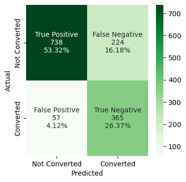

```python
#Calculating the confusion matrix
print(classification_report(y_test, y_pred_test2))
cm=confusion_matrix(y_test, y_pred_test2)
labels = ['True Positive','False Negative','False Positive','True Negative']
categories = [ 'Not Converted','Converted']
make_confusion_matrix(cm,
                      group_names=labels,
                      categories=categories,
                      figsize=(4,4),
                      cmap='Greens')
```

**Observations:**

- ~80% classification accuracy on both training and test dataset. tuned model not overfitting
- Model giving a generalized performance.
- Slightly improved recall score.
- Divergent recall score for converted and unconverted leads

### Visualizing the Decision Tree

**Let's visualize the tuned decision tree** and observe the decision rules:

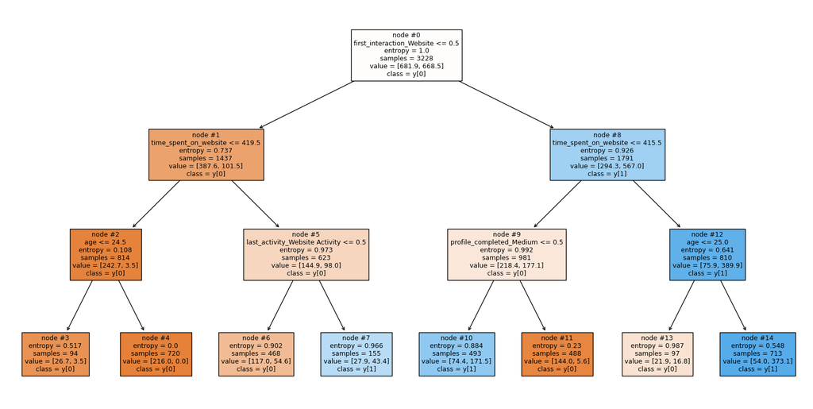

```python
features = list(X.columns)
plt.figure(figsize = (20, 10))
tree.plot_tree(d_tree_tuned, feature_names = features, filled = True, fontsize = 9, node_ids = True, class_names = True)
plt.show()
```

### **Feature importance** of the tuned decision tree model

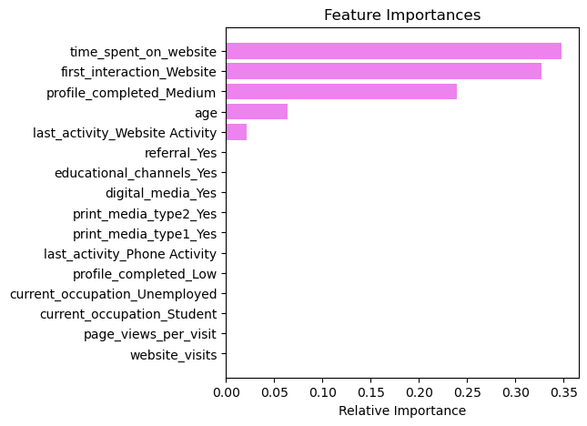

```python
# Plotting the relative feature importance
importances = d_tree_tuned.feature_importances_
indices = np.argsort(importances)
plt.figure(figsize = (5,5))
plt.title('Feature Importances')
plt.barh(range(len(indices)), importances[indices], color = 'violet', align = 'center')
plt.yticks(range(len(indices)), [features[i] for i in indices])
plt.xlabel('Relative Importance')
plt.show()
```

**Observations:**

- **Time spent on the website and first_interaction_website are the most important features** **followed by profile_completed, age, and last_activity**.
- **The rest of the variables have no impact in this model, while deciding whether a lead will be converted or not**.

## **Random Forest Classifier**

### Building Random Forest Model

```python
# Fitting the random forest tree classifier on the training data
rf_estimator = RandomForestClassifier(random_state=1)
rf_estimator.fit(X_train, y_train)
```

```
RandomForestClassifier(random_state=1)
```

#### Model Evaluation using K-Fold Cross Validation on Training data

```python
scores = cross_val_score(rf_estimator, X_train, y_train, cv=20)
print(f"The average accuracy score of the model with K-20 Cross validation is {np.average(scores)} ")
```

```
The average accuracy score of the model with K-20 Cross validation is 0.8525304807913503
```

**Performance on the testing data**

```python
# Checking performance on the testing data
y_pred_test3 = rf_estimator.predict(X_test)
```

```
              precision    recall  f1-score   support

           0       0.87      0.91      0.89       962
           1       0.78      0.68      0.73       422

    accuracy                           0.84      1384
   macro avg       0.82      0.80      0.81      1384
weighted avg       0.84      0.84      0.84      1384
```

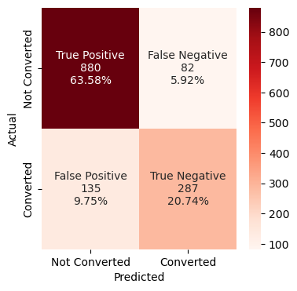

```python
#Calculating the confusion matrix
print(classification_report(y_test, y_pred_test3))
cm=confusion_matrix(y_test, y_pred_test3)
labels = ['True Positive','False Negative','False Positive','True Negative']
categories = [ 'Not Converted','Converted']
make_confusion_matrix(cm,
                      group_names=labels,
                      categories=categories,
                      figsize=(4,4),
                      cmap='Reds')
```

**Observations:**

- ~85% classification accuracy on both training and test dataset. Model not overfitting
- Model giving a generalized performance.
- 80% average recall score.
- Divergent recall score for converted and unconverted leads

### **Random Forest Classifier - Hyperparameter Tuning**

I'll try **tuning some of the important hyperparameters of the Random Forest Classifier**. I'll **not** tune the `criterion` hyperparameter as I know from hyperparameter tuning for decision trees that `entropy` is a better splitting criterion for this data.

```python
# Choose the type of classifier
rf_estimator_tuned = RandomForestClassifier(criterion = "entropy", random_state = 7)

# Grid of parameters to choose from
parameters = {"n_estimators": [110, 120],
    "max_depth": [6, 7],
    "min_samples_leaf": [20, 25],
    "max_features": [0.8, 0.9],
    "max_samples": [0.9, 1],
    "class_weight": ["balanced",{0: 0.3, 1: 0.7}]
             }

# Type of scoring used to compare parameter combinations - recall score for class 1
scorer = make_scorer(recall_score, pos_label = 1)

# Run the grid search on the training data using scorer=scorer and cv=5
grid_obj = GridSearchCV(rf_estimator_tuned, parameters, scoring = scorer, cv = 5)

grid_obj = grid_obj.fit(X_train, y_train)

# Save the best estimator to variable rf_estimator_tuned
rf_estimator_tuned = grid_obj.best_estimator_

#Fit the best estimator to the training data
rf_estimator_tuned.fit(X_train, y_train)
```

```
RandomForestClassifier(class_weight='balanced', criterion='entropy',
                       max_depth=6, max_features=0.8, max_samples=0.9,
                       min_samples_leaf=25, n_estimators=120, random_state=7)
```

#### Model Evaluation using K-Fold Cross Validation on Training data

```python
# Model Evaluation using K-Fold Cross Validation on Training data
scores = cross_val_score(rf_estimator_tuned, X_train, y_train, cv=20)
print(f"The average score of the model with K-20 Cross validation is {np.average(scores)} ")
```

```
The average score of the model with K-20 Cross validation is 0.8308431101909364
```

**Model performance on the test data**

```python
# Checking performance on the test data
y_pred_test4 = rf_estimator_tuned.predict(X_test)
```

```
              precision    recall  f1-score   support

           0       0.93      0.83      0.87       962
           1       0.68      0.85      0.76       422

    accuracy                           0.83      1384
   macro avg       0.81      0.84      0.82      1384
weighted avg       0.85      0.83      0.84      1384
```

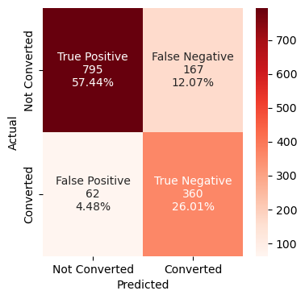

```python
#Calculating the confusion matrix
print(classification_report(y_test, y_pred_test4))
cm=confusion_matrix(y_test, y_pred_test4)
labels = ['True Positive','False Negative','False Positive','True Negative']
categories = [ 'Not Converted','Converted']
make_confusion_matrix(cm,
                      group_names=labels,
                      categories=categories,
                      figsize=(4,4),
                      cmap='Reds')
```

**Observations:**

- ~83% classification accuracy on both training and test dataset. Model not overfitting
- Model giving a generalized performance.
- 84% average recall score.
- Convergent recall scores for converted and unconverted leads

**One of the drawbacks of ensemble models is that we lose the ability to obtain an interpretation of the model. We cannot observe the decision rules for random forests the way we did for decision trees. So, i'll just check the feature importance of the model.**

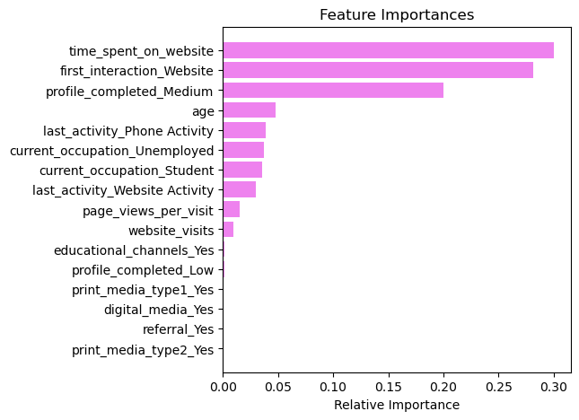

```python
importances = rf_estimator_tuned.feature_importances_
indices = np.argsort(importances)
feature_names = list(X.columns)
plt.figure(figsize = (5, 5))
plt.title('Feature Importances')
plt.barh(range(len(indices)), importances[indices], color = 'violet', align = 'center')
plt.yticks(range(len(indices)), [feature_names[i] for i in indices])
plt.xlabel('Relative Importance')
plt.show()
```

**Observations:**

- **Time spent on the website and first_interaction_website are the most important features** **followed by profile_completed, age and last_activity,**
- Similar feature importances with Decision Tree model

## Logistic Regression

```python
# Fitting the logistic regression model
lg = LogisticRegression(random_state=1)
lg.fit(X_train,y_train)
```

```
LogisticRegression(random_state=1)
```

#### Model Evaluation using K-Fold Cross Validation on Training data

```python
scores = cross_val_score(lg, X_train, y_train, cv=20)
print(f"The average accuracy score of the model with K-20 Cross validation is {np.average(scores)} ")
```

```
The average accuracy score of the model with K-20 Cross validation is 0.8227973314929837
```

#### Performance on the test dataset

```
              precision    recall  f1-score   support

           0       0.84      0.89      0.86       962
           1       0.71      0.61      0.66       422

    accuracy                           0.81      1384
   macro avg       0.78      0.75      0.76      1384
weighted avg       0.80      0.81      0.80      1384
```

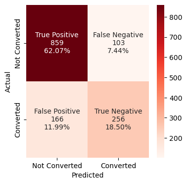

```python
#Calculating the confusion matrix
print(classification_report(y_test, y_pred_test5))
cm=confusion_matrix(y_test, y_pred_test5)
labels = ['True Positive','False Negative','False Positive','True Negative']
categories = [ 'Not Converted','Converted']
make_confusion_matrix(cm,
                      group_names=labels,
                      categories=categories,
                      figsize=(4,4),
                      cmap='Reds')
```

#### Coefficients of logistic regression

```python
cols = X.columns
coef_lg = lg.coef_
```

The coefficients of the logistic regression model give us the log of odds, which is hard to interpret in the real world. I can convert the log of odds into odds by taking its exponential.

```python
odds = np.exp(lg.coef_[0]) # Finding the odds
# Adding the odds to a DataFrame and sorting the values
pd.DataFrame(odds, X_train.columns, columns = ['odds']).sort_values(by = 'odds', ascending = False)
```

|  | odds |
| --- | --- |
| first_interaction_Website | 15.139 |
| referral_Yes | 1.618 |
| print_media_type2_Yes | 1.242 |
| last_activity_Website Activity | 1.202 |
| print_media_type1_Yes | 1.162 |
| digital_media_Yes | 1.042 |
| time_spent_on_website | 1.001 |
| educational_channels_Yes | 1.000 |
| age | 0.991 |
| website_visits | 0.989 |
| page_views_per_visit | 0.951 |
| current_occupation_Unemployed | 0.532 |
| profile_completed_Low | 0.504 |
| last_activity_Phone Activity | 0.398 |
| profile_completed_Medium | 0.207 |
| current_occupation_Student | 0.099 |

Observation:

- ~81% classification accuracy on both training and test dataset. Model not overfitting
- Model giving a generalized performance.
- 75% average recall score.
- Divergent recall scores for converted and unconverted leads
- First interaction on website has about 15 times odds of causing leads conversion than not

## K-Nearest Neighbour (KNN)

### Using GridSearchCV for Hyperparameter tuning of the KNN model

```python
# Choose the type of classifier
knn = KNeighborsClassifier()
# Grid of parameters to choose from
params_knn = {'n_neighbors': np.arange(3, 15), 'weights': ['uniform', 'distance'], 'p': [1, 2]}
#Type of scoring used to compare parameter combinations - recall score for class 1
scorer = make_scorer(recall_score, pos_label = 1)

grid_knn = GridSearchCV(knn, param_grid = params_knn, scoring = scorer, cv = 5)
grid_knn = grid_knn.fit(X_train,y_train)

# Save the best estimator to variable rf_estimator_tuned
knn_tuned = grid_knn.best_estimator_

#Fit the best estimator to the training data
knn_tuned.fit(X_train, y_train)
```

```
KNeighborsClassifier(n_neighbors=3, p=1, weights='distance')
```

#### Model Evaluation using K-Fold Cross Validation on Training data

```python
scores = cross_val_score(knn_tuned, X_train, y_train, cv=20)
print(f"The average accuracy score of the model with K-20 Cross validation is {np.average(scores)} ")
```

```
The average accuracy score of the model with K-20 Cross validation is 0.7001341921631776
```

#### Model performance on unseen test data

```
              precision    recall  f1-score   support

           0       0.77      0.81      0.79       962
           1       0.51      0.45      0.48       422

    accuracy                           0.70      1384
   macro avg       0.64      0.63      0.64      1384
weighted avg       0.69      0.70      0.70      1384
```

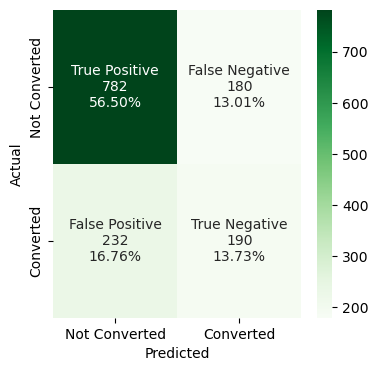

```python
#Calculating the confusion matrix
print(classification_report(y_test, y_pred6))
cm=confusion_matrix(y_test, y_pred6)
labels = ['True Positive','False Negative','False Positive','True Negative']
categories = [ 'Not Converted','Converted']
make_confusion_matrix(cm,
                      group_names=labels,
                      categories=categories,
                      figsize=(4,4),
                      cmap='Greens')
```

**Observations:**

- 70% classification accuracy on both training and test dataset. Model not overfitting
- Model giving a generalized performance.
- 63% average recall score.
- Divergent recall scores for converted and unconverted leads

## Linear Discriminant Analysis (LDA)

```python
# Fitting the LDA model
lda = LinearDiscriminantAnalysis()
lda.fit(X_train, y_train)
```

```
LinearDiscriminantAnalysis()
```

#### Model Evaluation using K-Fold Cross Validation on Training data

```python
scores = cross_val_score(lda, X_train, y_train, cv=20)
print(f"The average accuracy score of the model with K-20 Cross validation is {np.average(scores)} ")
```

```
The average accuracy score of the model with K-20 Cross validation is 0.8218714055670576
```

#### Model performance on unseen test data

```python
y_pred_test_lda = lda.predict(X_test)
```

```
              precision    recall  f1-score   support

           0       0.84      0.89      0.87       962
           1       0.72      0.62      0.67       422

    accuracy                           0.81      1384
   macro avg       0.78      0.76      0.77      1384
weighted avg       0.81      0.81      0.81      1384
```

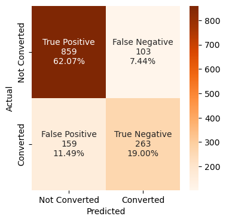

```python
#Calculating the confusion matrix
print(classification_report(y_test, y_pred_test_lda))
cm=confusion_matrix(y_test, y_pred_test_lda)
labels = ['True Positive','False Negative','False Positive','True Negative']
categories = [ 'Not Converted','Converted']
make_confusion_matrix(cm,
                      group_names=labels,
                      categories=categories,
                      figsize=(4,4),
                      cmap='Oranges')
```

```python
#checking the LDA coefficients to which variables boost/reduce customer conversion
# Creating the list of column names
cols = X.columns
# Saving coefficients of LDA model
coef_lda = lda.coef_
# Printing top 5 cofficients of LDA
pd.DataFrame(coef_lda, columns = cols).T.sort_values(by = 0, ascending = False).head()
```

|  | 0 |
| --- | --- |
| first_interaction_Website | 2.573 |
| referral_Yes | 1.753 |
| last_activity_Website Activity | 0.497 |
| print_media_type2_Yes | 0.423 |
| print_media_type1_Yes | 0.242 |

```python
#Printing least 5 cofficients of LDA
pd.DataFrame(coef_lda, columns = cols).T.sort_values(by = 0, ascending = False).tail()
```

|  | 0 |
| --- | --- |
| current_occupation_Unemployed | -0.609 |
| last_activity_Phone Activity | -0.632 |
| profile_completed_Medium | -1.689 |
| current_occupation_Student | -1.712 |
| profile_completed_Low | -2.031 |

Observations:

- ~82% classification accuracy on both training and test dataset. Model not overfitting
- Model giving a generalized performance.
- 76% average recall score.
- Divergent recall scores for converted and unconverted leads

## Quadratic Discriminant Analysis (QDA)

```python
# Fitting the QDA model
qda = QuadraticDiscriminantAnalysis()
qda.fit(X_train, y_train)
```

```
QuadraticDiscriminantAnalysis()
```

#### Model Evaluation using K-Fold Cross Validation on Training data

```python
scores = cross_val_score(qda, X_train, y_train, cv=20)
print(f"The average score of the model with K-20 Cross validation is {np.average(scores)} ")
```

```
The average score of the model with K-20 Cross validation is 0.8243367073077218
```

#### Model performance on unseen test data

```python
y_pred_test7 = qda.predict(X_test)
```

```
              precision    recall  f1-score   support

           0       0.88      0.85      0.86       962
           1       0.67      0.73      0.70       422

    accuracy                           0.81      1384
   macro avg       0.78      0.79      0.78      1384
weighted avg       0.82      0.81      0.81      1384
```

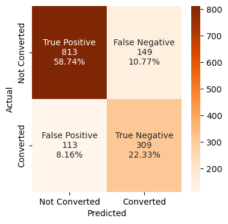

```python
#Calculating the confusion matrix
print(classification_report(y_test, y_pred_test7))
cm=confusion_matrix(y_test, y_pred_test7)
labels = ['True Positive','False Negative','False Positive','True Negative']
categories = [ 'Not Converted','Converted']
make_confusion_matrix(cm,
                      group_names=labels,
                      categories=categories,
                      figsize=(4,4),
                      cmap='Oranges')
```

Observations:

- ~82% classification accuracy on both training and test dataset. Model not overfitting
- Model giving a generalized performance.
- 79% average recall score.
- Divergent recall scores for converted and unconverted leads

## Adaboost Classifier

#### Using GridSearchCV for Hyperparameter tuning of the Adaboost model

```python
#Tuning to obtain optimal parameters
# Choose the type of classifier
AdaBoost_tuned = AdaBoostClassifier(random_state = 7)

# Grid of parameters to choose from
parameters = {"n_estimators": [50, 100, 150, 200],
    "learning_rate": [0.01, 0.1, 1]
             }

# Type of scoring used to compare parameter combinations - recall score for class 1
scorer = make_scorer(recall_score, pos_label = 1)
# Run the grid search on the training data using scorer=scorer and cv=5
grid_obj = GridSearchCV(AdaBoost_tuned, parameters, scoring = scorer, cv = 5)
grid_obj = grid_obj.fit(X_train, y_train)

# Save the best estimator to variable rf_estimator_tuned
AdaBoost_tuned = grid_obj.best_estimator_

#Fit the best estimator to the training data
AdaBoost_tuned.fit(X_train, y_train)
```

```
AdaBoostClassifier(learning_rate=1, n_estimators=150, random_state=7)
```

#### Model Evaluation using K-Fold Cross Validation on Training data

```python
scores = cross_val_score(AdaBoost_tuned, X_train, y_train, cv=20)
print(f"The average accuracy score of the model with K-20 Cross validation is {np.average(scores)} ")
```

```
The average accuracy score of the model with K-20 Cross validation is 0.8187869028448738
```

#### Model performance on unseen test data

```python
y_pred_test8 = AdaBoost_tuned.predict(X_test)
```

```
              precision    recall  f1-score   support

           0       0.86      0.90      0.88       962
           1       0.75      0.66      0.70       422

    accuracy                           0.83      1384
   macro avg       0.80      0.78      0.79      1384
weighted avg       0.82      0.83      0.82      1384
```

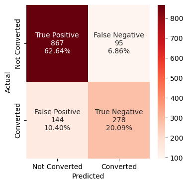

```python
#Calculating the confusion matrix
print(classification_report(y_test, y_pred_test8))
cm=confusion_matrix(y_test, y_pred_test8)
labels = ['True Positive','False Negative','False Positive','True Negative']
categories = [ 'Not Converted','Converted']
make_confusion_matrix(cm,
                      group_names=labels,
                      categories=categories,
                      figsize=(4,4),
                      cmap='Reds')
```

Observations:

- ~82% classification accuracy on both training and test dataset. Model not overfitting
- Model giving a generalized performance.
- 78% average recall score.
- Divergent recall scores for converted and unconverted leads

## Gradient Boost Classifier

#### Using GridSearchCV for Hyperparameter tuning of the Gradient Boost model

```python
#Tuning to obtain optimal parameters
# Choose the type of classifier
gbc = GradientBoostingClassifier(random_state = 7)

# Grid of parameters to choose from
parameters = {"n_estimators": [50, 100],
    "learning_rate": [0.01, 0.1, 1],
    "max_depth": [2,5,10],
    'min_samples_leaf': [5, 10, 20]
             }

# Type of scoring used to compare parameter combinations - recall score for class 1
scorer = make_scorer(recall_score, pos_label = 1)
# Run the grid search on the training data using scorer=scorer and cv=5
grid_obj = GridSearchCV(gbc, parameters, scoring = scorer, cv = 5)
grid_obj = grid_obj.fit(X_train, y_train)

# Save the best estimator to variable rf_estimator_tuned
gbc_tuned = grid_obj.best_estimator_

#Fit the best estimator to the training data
gbc_tuned.fit(X_train, y_train)
```

```
GradientBoostingClassifier(max_depth=2, min_samples_leaf=10, random_state=7)
```

#### Model Evaluation using K-Fold Cross Validation on Training data

```python
scores = cross_val_score(gbc_tuned, X_train, y_train, cv=20)
print(f"The average score of the model with K-20 Cross validation is {np.average(scores)} ")
```

```
The average score of the model with K-20 Cross validation is 0.8646173606318532
```

#### Model performance on unseen test data

```python
y_pred_test_gbc =gbc_tuned.predict(X_test)
```

```
              precision    recall  f1-score   support

           0       0.88      0.91      0.90       962
           1       0.78      0.73      0.75       422

    accuracy                           0.85      1384
   macro avg       0.83      0.82      0.82      1384
weighted avg       0.85      0.85      0.85      1384
```

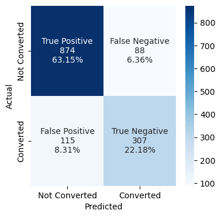

```python
#Calculating the confusion matrix
print(classification_report(y_test, y_pred_test_gbc))
cm=confusion_matrix(y_test, y_pred_test_gbc)
labels = ['True Positive','False Negative','False Positive','True Negative']
categories = [ 'Not Converted','Converted']
make_confusion_matrix(cm,
                      group_names=labels,
                      categories=categories,
                      figsize=(4,4),
                      cmap='Blues')
```

Observations:

- ~86% classification accuracy on both training and test dataset. Model not overfitting
- Model giving a generalized performance.
- 82% average recall score.
- Divergent recall scores for converted and unconverted leads

## XGBoost Classifier

#### Using GridSearchCV for Hyperparameter tuning of the XGBoost model

```python
#Tuning to obtain optimal parameters
# Choose the type of classifier
xgb = XGBClassifier(random_state = 7)

# Grid of parameters to choose from
parameters = {
    "booster": ['gbtree', 'gblinear', 'dart']
             }

# Type of scoring used to compare parameter combinations - recall score for class 1
scorer = make_scorer(recall_score, pos_label = 1)
# Run the grid search on the training data using scorer=scorer and cv=5
grid_obj = GridSearchCV(xgb, parameters, scoring = scorer, cv = 5)
grid_obj = grid_obj.fit(X_train, y_train)

# Save the best estimator to variable rf_estimator_tuned
xgb_tuned = grid_obj.best_estimator_

#Fit the best estimator to the training data
xgb_tuned.fit(X_train, y_train)
```

```
XGBClassifier(base_score=None, booster='gbtree', callbacks=None,
              colsample_bylevel=None, colsample_bynode=None,
              colsample_bytree=None, early_stopping_rounds=None,
              enable_categorical=False, eval_metric=None, feature_types=None,
              gamma=None, gpu_id=None, grow_policy=None, importance_type=None,
              interaction_constraints=None, learning_rate=None, max_bin=None,
              max_cat_threshold=None, max_cat_to_onehot=None,
              max_delta_step=None, max_depth=None, max_leaves=None,
              min_child_weight=None, missing=nan, monotone_constraints=None,
              n_estimators=100, n_jobs=None, num_parallel_tree=None,
              predictor=None, random_state=7, ...)
```

#### Model Evaluation using K-Fold Cross Validation on Training data

```python
scores = cross_val_score(xgb_tuned, X_train, y_train, cv=20)
print(f"The average accuracy score of the model with K-20 Cross validation is {np.average(scores)} ")
```

```
The average accuracy score of the model with K-20 Cross validation is 0.8370504562533547
```

#### Model performance on unseen test data

```python
y_pred_test_xgb = xgb_tuned.predict(X_test)
```

```
              precision    recall  f1-score   support

           0       0.88      0.90      0.89       962
           1       0.76      0.72      0.74       422

    accuracy                           0.85      1384
   macro avg       0.82      0.81      0.81      1384
weighted avg       0.84      0.85      0.84      1384
```

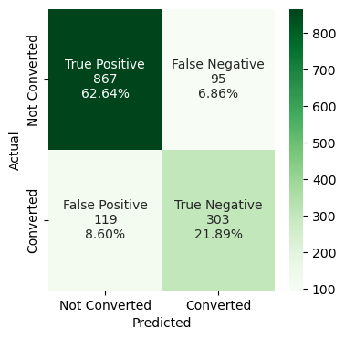

```python
#Calculating the confusion matrix
print(classification_report(y_test, y_pred_test_xgb))
cm=confusion_matrix(y_test, y_pred_test_xgb)
labels = ['True Positive','False Negative','False Positive','True Negative']
categories = [ 'Not Converted','Converted']
make_confusion_matrix(cm,
                      group_names=labels,
                      categories=categories,
                      figsize=(4,4),
                      cmap='Greens')
```

Observations:

- ~85% classification accuracy on both training and test dataset. Model not overfitting
- Model giving a generalized performance.
- 81% average recall score.
- Divergent recall scores for converted and unconverted leads

## Bagging Classifier

#### Using GridSearchCV for Hyperparameter tuning of the Bagging model

```python
bagging_tuned = BaggingClassifier(random_state = 7)

# Grid of parameters to choose from
parameters = {"n_estimators": [10, 15, 20],
              "max_samples": [0.01,0.1,0.2,0.4,0.8, 1],
              "max_features": [0.01,0.1,0.2,0.4,0.8, 1]
             }
# Type of scoring used to compare parameter combinations
scorer = make_scorer(recall_score, pos_label = 1)
# Run the grid search
grid_obj = GridSearchCV(bagging_tuned, parameters, scoring = scorer, cv = 5)
grid_obj = grid_obj.fit(X_train, y_train)

# Set the bagging_tuned_regressor to the best combination of parameters
bagging_tuned = grid_obj.best_estimator_

bagging_tuned.fit(X_train, y_train)
```

```
BaggingClassifier(max_features=0.8, max_samples=0.4, n_estimators=15,
                  random_state=7)
```

#### Model Evaluation using K-Fold Cross Validation on Training data

```python
scores = cross_val_score(bagging_tuned, X_train, y_train, cv=20)
print(f"The average score of the model with K-20 Cross validation is {np.average(scores)} ")
```

```
The average score of the model with K-20 Cross validation is 0.8317632850241546
```

#### Model performance on test data

```python
y_pred_test_bagg = bagging_tuned.predict(X_test)
```

```
              precision    recall  f1-score   support

           0       0.86      0.91      0.89       962
           1       0.77      0.67      0.72       422

    accuracy                           0.84      1384
   macro avg       0.82      0.79      0.80      1384
weighted avg       0.84      0.84      0.84      1384
```

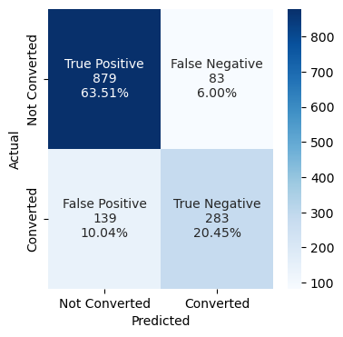

```python
#Calculating the confusion matrix
print(classification_report(y_test, y_pred_test_bagg))
cm=confusion_matrix(y_test, y_pred_test_bagg)
labels = ['True Positive','False Negative','False Positive','True Negative']
categories = [ 'Not Converted','Converted']
make_confusion_matrix(cm,
                      group_names=labels,
                      categories=categories,
                      figsize=(4,4),
                      cmap='Blues')
```

Observations:

- ~85% classification accuracy on both training and test dataset. Model not overfitting
- Model giving a generalized performance.
- 79% average recall score.
- Divergent recall scores for converted and unconverted leads

## Performance Comparison of all the Classifier models built

```python
def model_performance_classification(model, predictors, target):
    """
    Function to compute different metrics to check classification model performance
    model: classifier
    predictors: independent variables
    target: dependent variable
    """
    # Predicting using the independent variables
    pred = model.predict(predictors)
    recall = recall_score(target, pred,average = 'macro')                 # To compute recall
    precision = precision_score(target, pred, average = 'macro')              # To compute precision
    acc = accuracy_score(target, pred)                                 # To compute accuracy score
    f1__score = f1_score(target, pred, average = 'macro')
    # Creating a dataframe of metrics
    df_perf = pd.DataFrame(
        {
            "Precision":  precision,
            "Recall":  recall,
            "f1-Score": f1__score,
            "Accuracy": acc,
        },

        index = [0],
    )

    return df_perf
```

```python
dtree_test_tuned = model_performance_classification(d_tree_tuned,X_test,y_test)
rf_test_tuned = model_performance_classification(rf_estimator_tuned,X_test,y_test)
knn_test_tuned = model_performance_classification(knn_tuned,X_test,y_test)
lda_test_tuned = model_performance_classification(lda,X_test,y_test)
qda_test_tuned = model_performance_classification(qda,X_test,y_test)
adaboost_test_tuned = model_performance_classification(AdaBoost_tuned,X_test,y_test)
gbc_test_tuned = model_performance_classification(gbc_tuned,X_test,y_test)
xgb_test_tuned = model_performance_classification(xgb_tuned,X_test,y_test)
bagging_test_tuned = model_performance_classification(bagging_tuned,X_test,y_test)
logistic_test = model_performance_classification(lg,X_test,y_test)
```

```python
models_test_comp_df = pd.concat(
    [dtree_test_tuned.T, rf_test_tuned.T,adaboost_test_tuned.T, gbc_test_tuned.T, xgb_test_tuned.T,logistic_test.T,bagging_test_tuned.T,
    knn_test_tuned.T,lda_test_tuned.T,qda_test_tuned.T],
    axis = 1,
)
models_test_comp_df.columns = [
    "Tuned Decision Tree classifier",
    "Tuned Random Forest classifier",
    "Tuned Adaboost classifier",
    "Tuned Gradientboost classifier",
    "Tuned XGBoost classifier",
    "Logistic Regression",
    "Tuned Bagging",
    "Tuned KNN",
    "LDA",
    "QDA"
]
print("Test performance comparison:")
```

```
Test performance comparison:
```

```python
models_test_comp_df.T.style.highlight_max(color = "lightgreen", axis = 0)
```

|  | Precision | Recall | f1-Score | Accuracy |
| --- | --- | --- | --- | --- |
| Tuned Decision Tree classifier | 0.773998 | 0.816040 | 0.781063 | 0.796965 |
| Tuned Random Forest classifier | 0.805383 | 0.839742 | 0.816400 | 0.834538 |
| Tuned Adaboost classifier | 0.801438 | 0.780008 | 0.789118 | 0.827312 |
| Tuned Gradientboost classifier | 0.830468 | 0.818006 | 0.823740 | 0.853324 |
| Tuned XGBoost classifier | 0.820308 | 0.809628 | 0.814584 | 0.845376 |
| Logistic Regression | 0.775570 | 0.749783 | 0.760095 | 0.805636 |
| Tuned Bagging | 0.818341 | 0.792169 | 0.803076 | 0.839595 |
| Tuned KNN | 0.642358 | 0.631563 | 0.635648 | 0.702312 |
| LDA | 0.781195 | 0.758077 | 0.767595 | 0.810694 |
| QDA | 0.776321 | 0.788671 | 0.781751 | 0.810694 |